# Highlighting high influence observations in ggplot2

Individual Study

10/12/2021

The next task is to use ‘base ggplot’ to show high influence observations.

Below, you will see two plots produced with ‘base R graphics’. These are from - https://www.stat.berkeley.edu/~spector/s133/Lr1.html

You will reproduce with ggplot2.

## First we read in data, and limit to variables of interest, Alcohol and Proline.

```r
library(tidyverse)
wine_raw <- read_csv("https://gist.githubusercontent.com/tijptjik/9408623/raw/b237fa5848349a14a14e5d4107dc7897c21951f5/wine.csv")

head(wine_raw)
```

```
## # A tibble: 6 x 14
##    Wine Alcohol Malic.acid   Ash   Acl    Mg Phenols Flavanoids Nonflavanoid.ph…
##   <dbl>   <dbl>      <dbl> <dbl> <dbl> <dbl>   <dbl>      <dbl>            <dbl>
## 1     1    14.2       1.71  2.43  15.6   127    2.8        3.06             0.28
## 2     1    13.2       1.78  2.14  11.2   100    2.65       2.76             0.26
## 3     1    13.2       2.36  2.67  18.6   101    2.8        3.24             0.3
## 4     1    14.4       1.95  2.5   16.8   113    3.85       3.49             0.24
## 5     1    13.2       2.59  2.87  21     118    2.8        2.69             0.39
## 6     1    14.2       1.76  2.45  15.2   112    3.27       3.39             0.34
## # … with 5 more variables: Proanth <dbl>, Color.int <dbl>, Hue <dbl>, OD <dbl>,
## #   Proline <dbl>
```

```r
wine_raw %>%
  select(Alcohol, Proline) ->
wine

head(wine)
```

```
## # A tibble: 6 x 2
##   Alcohol Proline
##     <dbl>   <dbl>
## 1    14.2    1065
## 2    13.2    1050
## 3    13.2    1185
## 4    14.4    1480
## 5    13.2     735
## 6    14.2    1450
```

## Then we estimate a linear model (ols).

```r
# estimate a linear model and assign to simple.lm
# we will only be looking at simple lm (one predictor) for the independent study
simple.lm <- lm(formula = Alcohol ~ Proline,
                data = wine_raw)
```

## Once estimated, we can get a vector of cooks distances and leverage values for each observation. We add these to the data frame.

```r
# save cooks distance for each observation using $ notation
# Cook, R. Dennis (February 1977). "Detection of Influential Observations in Linear Regression". Technometrics. American Statistical Association. 19 (1): 15–18. doi:10.2307/1268249. JSTOR 1268249. MR 0436478.
# https://en.wikipedia.org/wiki/Cook%27s_distance
# as another variable in the wine data frame
wine$cooks <- cooks.distance(model = simple.lm)

# save 'hat' calculation (leverage I think - we'll have to come back to exact calculation)
# as another variable inthe wine data frame
wine$hat <-  lm.influence(model = simple.lm)$hat
wine
```

```
## # A tibble: 178 x 4
##    Alcohol Proline     cooks     hat
##      <dbl>   <dbl>     <dbl>   <dbl>
##  1    14.2    1065 0.00738   0.0114
##  2    13.2    1050 0.00132   0.0109
##  3    13.2    1185 0.00710   0.0166
##  4    14.4    1480 0.00117   0.0362
##  5    13.2     735 0.000492  0.00563
##  6    14.2    1450 0.0000495 0.0338
##  7    14.4    1290 0.00720   0.0224
##  8    14.1    1295 0.000688  0.0227
##  9    14.8    1045 0.0250    0.0107
## 10    13.9    1045 0.00187   0.0107
## # … with 168 more rows
```

## What follows are the examples from https://www.stat.berkeley.edu/~spector/s133/Lr1.html which build plots using base r graphics.

### Note: looking just at the code `wine$cooks > quantile(wine$cooks, .90)` might be helpful. What does `quantile(wine$cooks, .90)` return? And the inequality?

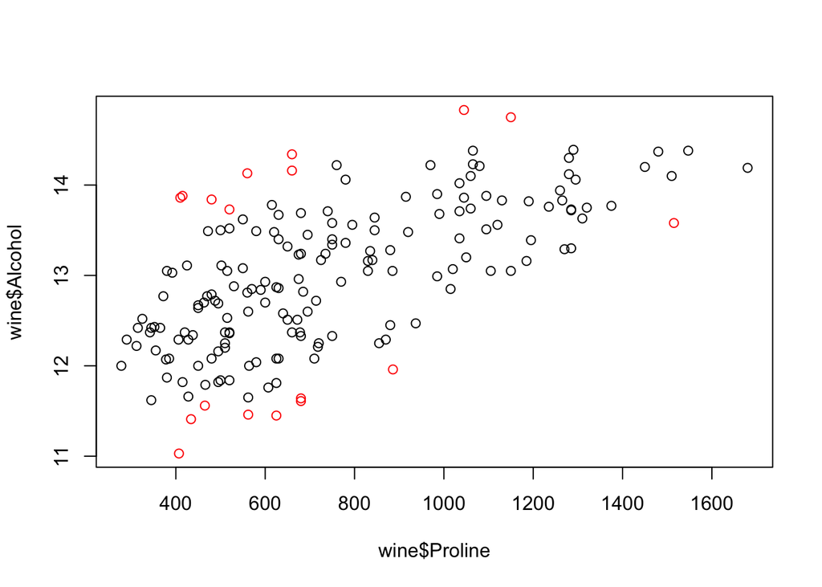

```r
# base R plot highlighting 10% highest cooks
plot(x = wine$Proline, y = wine$Alcohol,
     col = ifelse(test = wine$cooks >
                    quantile(wine$cooks, .90),
                  yes = 'red',
                  no = 'black'))
```

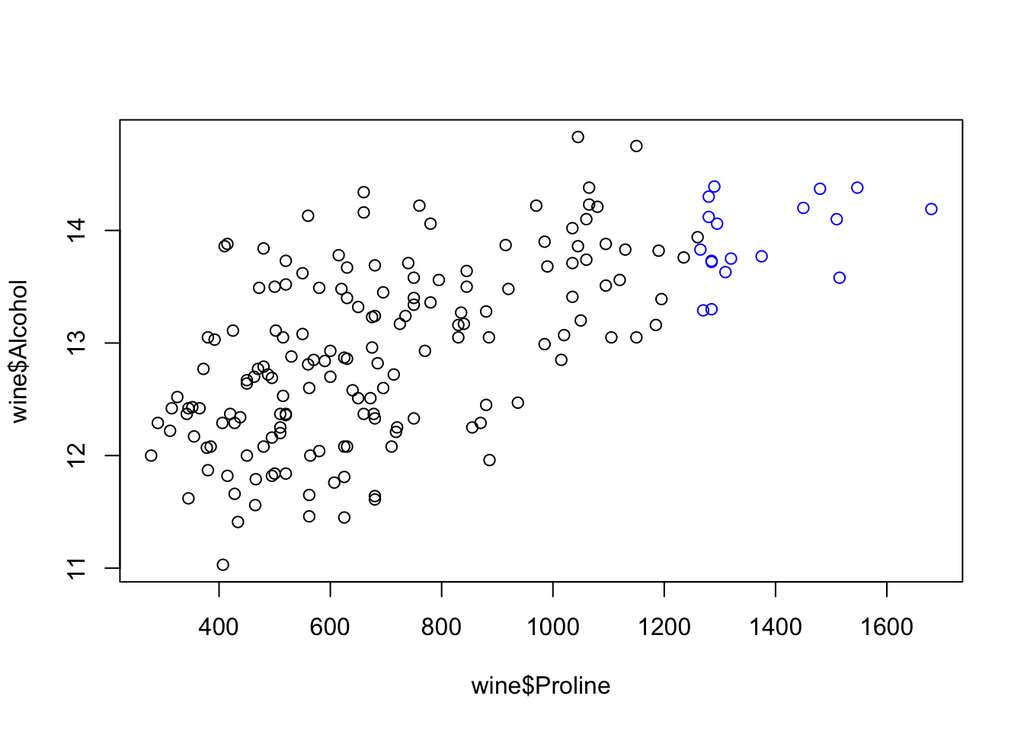

```r
# base R plot highlighting 10% highest leverage (hat)
plot(x = wine$Proline,
     y = wine$Alcohol,
     col=ifelse(wine$hat > quantile(wine$hat,.90),
                'blue','black'))
```

## Now, with ggplot2, we’ll use two point layers to build very similar plots

- First, plot all the observations.
- Then, plot 10% of observations with largest cook’s (or largest hat) in highlight color.

### Need a hint? Below, the second point layer highlights a subset of points.

### Note: in base R we refer to variables w/ dollar sign notation, but in tidyverse/ggplot2, you can use variable names directly (i.e. Proline instead of wine$Proline)

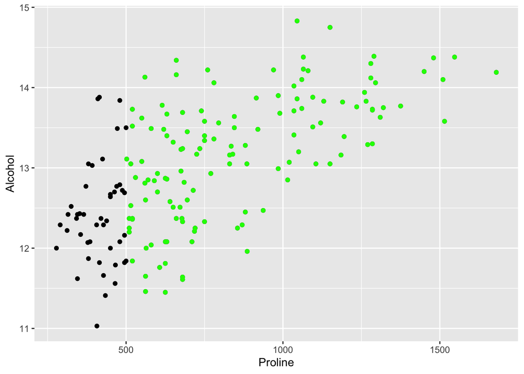

```r
# An example of defining subset of data for a point layer
ggplot(data = wine) +
  aes(x = Proline) +
  aes(y = Alcohol) +
  geom_point() + # this point layer ALL data default color black
  geom_point(data = wine %>% # this next point layer
               filter(Proline > 500), # SUBSET of data
             color = "green") # custom color
```

# Task 4.2

Now, Instead of highlighting a subset, label each point with cooks distance. (hint - you can use the geom_text()).

Here is an example of where the observations are labeled with the Alcohol level.

What does nudge_y do? What does check_overlap do?

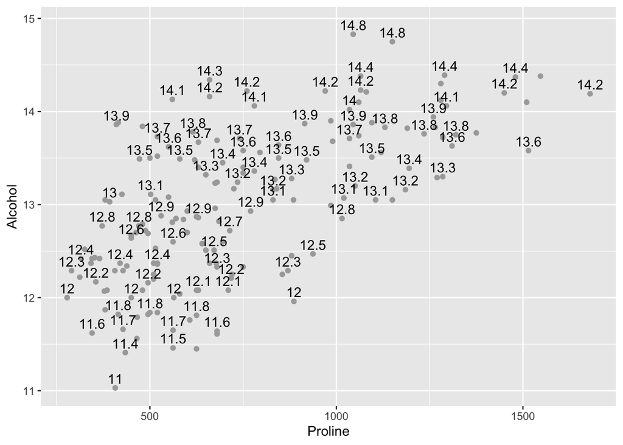

```r
ggplot(data = wine) +
  aes(x = Proline) +
  aes(y = Alcohol) +
  geom_point(color = "darkgrey") +
  aes(label = round(Alcohol, 1)) +
  geom_text(nudge_y = .1,
            check_overlap = T)
```

Right now we aren’t writing any new functions, rather just using ggplot2 ‘out-of-the-box’.